### Madrid, December, 2023.

# Project 2, Part1, F1 Material Transportation with Minimum Cost Flow Problem

## Author: Alejo González García

For this project, let´s say we are the FIA, Federation Internationale de l'Automobile. In Formula 1, each year, many countries around the world are visited. For our problem we are going to visit 15 cities in most of the continents.

The problem we have to solve consists in satisfying the demand on each race week but trying to minimize the cost. Each of the paths that we have, have an associated cost that measures all the money we have to spend if we use that path in 100$ per ton of cargo. We want to satisfy all the demand but making sure to use the most optimal path. Remark that we do not need to use the full a capacity of a link, we have the maximum tons we can send and the money that each of those tons costs.

In order to reduce costs, the FIA, has located it´s production factories in just a few cities around the world (Montreal, São Paulo, Singapore and Vegas). This cities are going to be shown in the graph as the ones with positive demand in blue color. The cities that do not produce materials, but need them, will be shown in red color with a negative demand.

We assume the productor cities satisfy their own demand and the transportation cost is null.

```python
# HW2
import numpy as np
import networkx as nx
import matplotlib.pyplot as plt
from pyomo.environ import *
from mpl_toolkits.basemap import Basemap # this library is super cool and let´s us plot whatever we want regarding maps
import matplotlib.patches as mpatches
from pyomo.opt import *


# Set seed for reproducibility
np.random.seed(30)

# We are defining the geographical coordinates of the cities
coordinates = {
    'Vegas':           (36.1699, -115.1398),
    'San Petersburgh': (59.937500, 30.30861),
    'Jeddah':          (21.389, 39.8579),
    'Melbourne':       (-37.8136, 144.9631),
    'Baku':            (40.4093, 49.8671),
    'Miami':           (25.7617, -80.1918),
    'São Paulo':       (-23.5337, -46.6252),
    'Valencia':        (39.4666, -0.375000),
    'Singapore':       (1.2902, 103.8519),
    'Montreal':        (45.5017, -73.5673),
    'Imola':           (44.353058, 11.714722),
    'Silverstone':     (52.073273, -1.014818),
    'China':           (35,105),
    'Abu Dhabi':       (24.4539, 54.3773),
    'Mexico':          (19.42847, -99.12766)
}

nodes  = ['Vegas','Miami','Jeddah', 'Melbourne', 'Baku', 'San Petersburgh', 'São Paulo','Valencia','Singapore','Montreal','Imola','Silverstone', 'China', 'Mexico', 'Abu Dhabi']
demand = [    250,    -80,     -25,         -50,    -60,               -35,          85,       -30,         75,       115,    -40,          -30,     -25,      -50,        -100]
# Each node is one of the cities we have in the F1 calendar.
# Demand are the tons of cargo I want to move from one city to another in an optimal way.
# Positive demand means that city is a productor and negative demand means that amount of cargo must be delivered to that city

arcs =  [('Vegas', 'San Petersburgh'),     ('San Petersburgh', 'Jeddah'),   ('Jeddah', 'São Paulo'),     ('San Petersburgh', 'Abu Dhabi'),     ('Vegas', 'Abu Dhabi'),      ('Singapore','China'),
         ('Jeddah','Baku'),                ('Valencia', 'São Paulo'),       ('Valencia','Singapore'),    ('Singapore','Montreal'),             ('Miami','Silverstone'),     ('China','Baku'),
         ('Montreal','Silverstone'),       ('Melbourne', 'Baku'),           ('Melbourne', 'Abu Dhabi'),  ('Baku', 'San Petersburgh'),          ('Melbourne','Miami'),       ('São Paulo', 'Silverstone'),
         ('São Paulo', 'Valencia'),        ('Montreal', 'Miami'),           ('Montreal','Imola'),        ('Imola','Abu Dhabi'),                ('Silverstone','Abu Dhabi'), ('Singapore', 'Melbourne'),
         ('Vegas','São Paulo'),            ('São Paulo','Melbourne'),       ('Abu Dhabi','China'),       ('Mexico', 'Miami'),                  ('Silverstone', 'Valencia'), ('Vegas', 'Miami'),
         ('Vegas', 'Mexico'),              ('São Paulo', 'Miami'),          ('Silverstone', 'Baku'),     ('Imola', 'San Petersburgh')
         ]
# This are all the possible paths or connections that we have between the cities

edges = { # origin city, dest city, capacity (tons), cost_dollar (100$/ton), cost_time (hours)
         ('San Petersburgh', 'Jeddah'):     (50, 15, 3, "Air"),
         ('Jeddah', 'São Paulo'):           (55, 40, 3,  "Train"),
         ('Vegas', 'Miami'):                (75, 100,3, "Ship"),
         ('Vegas', 'San Petersburgh'):      (50, 25, 3, "Ship"),
         ('San Petersburgh', 'Abu Dhabi'):  (80, 10, 3, "Train"),
         ('Vegas', 'Abu Dhabi'):            (85, 35, 2, "Air"),
         ('Jeddah','Baku'):                 (90, 20, 3,  "Ship"),
         ('Valencia', 'São Paulo'):         (65, 45, 3,  "Train"),
         ('Valencia','Singapore'):          (90, 60, 3,  "Ship"),
         ('Singapore','Montreal'):          (80, 15, 3,  "Air"),
         ('Montreal','Silverstone'):        (50, 45, 3,  "Ship"),
         ('Miami','Silverstone'):           (50, 35, 3,  "Train"),
         ('Melbourne','Miami'):             (120,80, 3,  "Air"),
         ('Melbourne', 'Baku'):             (130,85, 3,  "Ship"),
         ('Melbourne', 'Abu Dhabi'):        (25, 50, 3,  "Train"),
         ('Baku', 'San Petersburgh'):       (40, 60, 3,  "Ship"),
         ('São Paulo', 'Silverstone'):      (110,40, 3,  "Air"),
         ('São Paulo', 'Valencia'):         (150,50, 3,  "Ship"),
         ('Montreal', 'Miami'):             (50, 80, 3,  "Air"),
         ('Montreal','Imola'):              (90, 55, 3,  "Train"),
         ('Silverstone','Abu Dhabi'):       (65, 30, 3,  "Air"),
         ('Imola','Abu Dhabi'):             (75, 45, 3,  "Ship"),
         ('China','Baku'):                  (50, 25, 3,  "Train"),
         ('Singapore','China'):             (200,75, 3,  "Ship"),
         ('Vegas','São Paulo'):             (110,70, 3,  "Ship"),
         ('São Paulo','Melbourne'):         (100,120,  3,  "Train"),
         ('Abu Dhabi','China'):             (40, 15, 3,  "Train"),
         ('Mexico', 'Miami'):               (40, 15, 3,  "Air"),
         ('Silverstone', 'Valencia'):       (60, 30, 3,  "Air"),
         ('Singapore', 'Melbourne'):        (80, 100,3,  "Air"),
         ('Vegas', 'Mexico'):               (65, 70, 3,  "Ship"),
         ('São Paulo', 'Miami'):            (20, 80, 3,  "Air"),
         ('Silverstone', 'Baku'):           (20, 35, 3,  "Air"),
         ('Imola', 'San Petersburgh'):      (30, 35, 3,  "Train"),
         }

capacities =   [edge[0] for edge in edges.values()]
cost_dollars = [edge[1] for edge in edges.values()]
cost_time =    [edge[2] for edge in edges.values()]
transport =    [edge[3] for edge in edges.values()]

# Check if the sum of the demand vector is zero, otherwise the solution is not feasible!
print("Is the sum of demand zero? Can we have a solution?", sum(demand) == 0, ", Total sum is:", sum(demand))
```

```
Is the sum of demand zero? Can we have a solution? True , Total sum is: 0
```

Now we are going to check for correctness while developing the model:

```python
print("Nodes: ", nodes, len(nodes))
print("Number of Arcs:", len(arcs), "Number of Edges:", len(edges))
print("Demands:", demand , len(demand))
print("Capacities:", capacities, len(capacities))
print("cost_dollars (100$/ton):", cost_dollars, len(cost_dollars))
print("cost_time:", cost_time, len(cost_time))
```

```
Nodes:  ['Vegas', 'Miami', 'Jeddah', 'Melbourne', 'Baku', 'San Petersburgh', 'São Paulo', 'Valencia', 'Singapore', 'Montreal', 'Imola', 'Silverstone', 'China', 'Mexico', 'Abu Dhabi'] 15
Number of Arcs: 34 Number of Edges: 34
Demands: [250, -80, -25, -50, -60, -35, 85, -30, 75, 115, -40, -30, -25, -50, -100] 15
Capacities: [50, 55, 75, 50, 80, 85, 90, 65, 90, 80, 50, 50, 120, 130, 25, 40, 110, 150, 50, 90, 65, 75, 50, 200, 110, 100, 40, 40, 60, 80, 65, 20, 20, 30] 34
cost_dollars (100$/ton): [15, 40, 100, 25, 10, 35, 20, 45, 60, 15, 45, 35, 80, 85, 50, 60, 40, 50, 80, 55, 30, 45, 25, 75, 70, 120, 15, 15, 30, 100, 70, 80, 35, 35] 34
cost_time: [3, 3, 3, 3, 3, 2, 3, 3, 3, 3, 3, 3, 3, 3, 3, 3, 3, 3, 3, 3, 3, 3, 3, 3, 3, 3, 3, 3, 3, 3, 3, 3, 3, 3] 34
```

Now we are going to try to gain some insights about the data we have. First of all, by plotting the Capacity and Cost for each of the links we have:

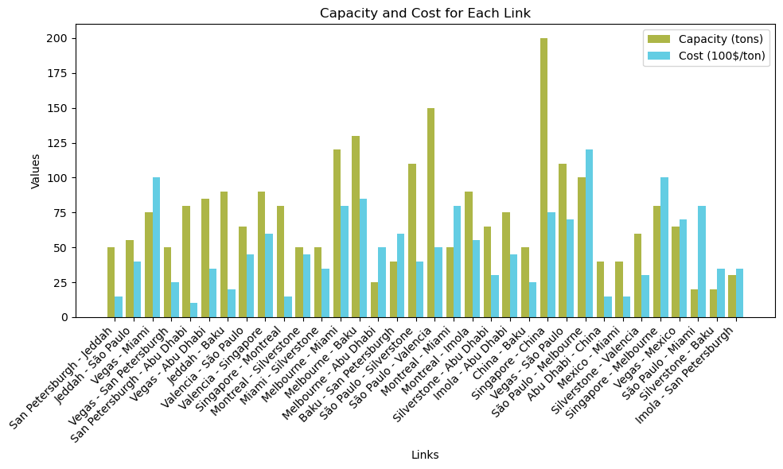

```python
# Extract data from edges dictionary
link_names = [f"{edge[0]} - {edge[1]}" for edge in edges.keys()]

# Create a bar plot
fig, ax = plt.subplots(figsize=(10, 6))
bar_width = 0.4
index = range(len(link_names))

# Bar for capacities
bars1 = ax.bar(index, capacities, bar_width, label='Capacity (tons)', color='#adb647')

# Bar for cost in dollars
bars2 = ax.bar([i + bar_width for i in index], cost_dollars, bar_width, label='Cost (100$/ton)', color='#63cde3')

# Add labels, title, and legend
ax.set_xlabel('Links')
ax.set_ylabel('Values')
ax.set_title('Capacity and Cost for Each Link')
ax.set_xticks([i + bar_width/2 for i in index])
ax.set_xticklabels(link_names, rotation=45, ha="right")  # Rotate labels by 45 degrees
ax.legend()

# Show the plot
plt.tight_layout()
plt.show()
```

We can see that there is a lot of variation between the cost and the capacity, and in a barplot it is going to be hard to determine whether this relationship is linear or not. With a scatterplot we can see it:

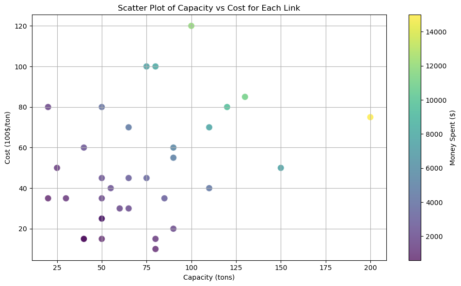

```python
# Calculate money spent for each link
money_spent = [cap * cost for cap, cost in zip(capacities, cost_dollars)]

# Create a scatter plot
fig, ax = plt.subplots(figsize=(10, 6))

# Scatter plot for capacities and cost
scatter = ax.scatter(capacities, cost_dollars, c=money_spent, cmap='viridis', s=100, alpha=0.7, edgecolors='w')

# Add labels, title, and colorbar
ax.set_xlabel('Capacity (tons)')
ax.set_ylabel('Cost (100$/ton)')
ax.set_title('Scatter Plot of Capacity vs Cost for Each Link')
ax.grid(True)

# Add colorbar
cbar = plt.colorbar(scatter)
cbar.set_label('Money Spent ($)')

# Show the plot
plt.tight_layout()
plt.show()
```

This plot is really interesting because we can see that for the provided data, the relation between Cost and Capacity is NOT linear. It is true that we can see that there is kind of a pattern between the points but there are lot of points that do not follow a trend. To be linear we should see some kind of aligment of the data and it´s not the case. We can see that the some links are truly expensive and for some of them the capacity is not that high.

We are going to see now the relationship between the capacity * cost, that is the money spent in a link if the full capacity is used. This will give us insights about which links must be used and which ones must not.

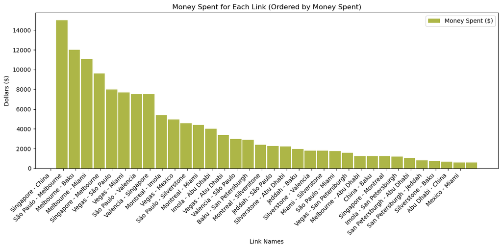

```python
# Sort data by money spent
sorted_indices = sorted(range(len(money_spent)), key=lambda k: money_spent[k], reverse=True)
link_names = [link_names[i] for i in sorted_indices]
money_spent = [money_spent[i] for i in sorted_indices]

# Create a bar plot
fig, ax = plt.subplots(figsize=(12, 6))
bar_width = 0.9
index = range(len(link_names))

# Bar for money spent
bars3 = ax.bar([i + 2 * bar_width for i in index], money_spent, bar_width, label='Money Spent ($)', color='#adb647')

# Add labels, title, and legend
ax.set_xlabel('Link Names')
ax.set_ylabel('Dollars ($)')
ax.set_title('Money Spent for Each Link (Ordered by Money Spent)')
ax.set_xticks([i + bar_width for i in index])
ax.set_xticklabels(link_names, rotation=45, ha="right")  # Rotate labels by 45 degrees
ax.legend()

# Show the plot
plt.tight_layout()
plt.show()
```

This plot give provides a lot of information. We can see that the link where we can spend more money is Singapore-China and smallest one is Mexico-Miami. This could be influenced by the type of transport used, the taxes of those countries or the distance between those two cities. We have to take into account that maybe a link is quite expensive but the number of kilometers is also proportional, that is the case, for the link Sao Paulo - Melbourne, ie, Brazil-Australia. The distance is huge and the cost is proportional. In this case study we are not going to focus on kilometers, as we assume that is included and considered in the cost. Just focus on minimize the cost for transporting the cargo between cities. Let´s plot the cost and see:

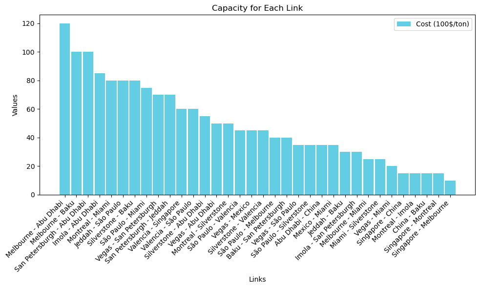

```python
# Create a list of tuples containing link names and corresponding costs
link_cost_tuples = list(zip(link_names, cost_dollars))

# Sort the list of tuples by cost in descending order (the second element in each tuple)
sorted_link_cost_tuples = sorted(link_cost_tuples, key=lambda x: x[1], reverse=True)

# Unpack the sorted tuples to get the sorted link names and costs
sorted_link_names, sorted_costs = zip(*sorted_link_cost_tuples)

# Create a bar plot
fig, ax = plt.subplots(figsize=(10, 6))
bar_width = 0.9
index = range(len(sorted_link_names))

# Bar for cost in dollars
bars2 = ax.bar(index, sorted_costs, bar_width, label='Cost (100$/ton)', color='#63cde3')

# Add labels, title, and legend
ax.set_xlabel('Links')
ax.set_ylabel('Values')
ax.set_title('Capacity for Each Link')
ax.set_xticks(index)
ax.set_xticklabels(sorted_link_names, rotation=45, ha="right")  # Rotate labels by 45 degrees
ax.legend()

# Show the plot
plt.tight_layout()
plt.show()
```

It is quite important to have an idea of how this network is. For this purpuose I have developed a map that shows the exact geographical point of each node and places a label between each link. Remark that I have used a combination of the networkx and basemap libraries. The first one to deal with the network, nodes and paths. The second to deal with the map and locations.

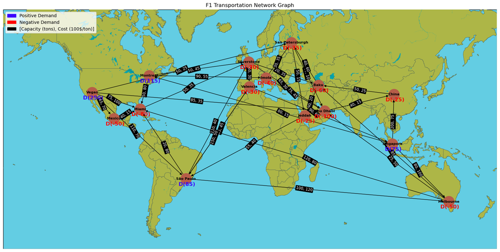

```python
# Create a graph
G = nx.DiGraph() # Notice that the "Di" part is the one that allows us to see the direction of each path, showing the arrows

# Add nodes with coordinates
for node, coord in coordinates.items():
    G.add_node(node, pos=coord)

# Add edges
G.add_edges_from(arcs)

# Draw the graph on a map
fig, ax = plt.subplots(figsize=(20, 18))
m = Basemap(projection='merc', llcrnrlat=-60, urcrnrlat=70, llcrnrlon=-180, urcrnrlon=180, resolution='l')
m.drawcoastlines(color='#3d5758', linewidth=1, zorder=1)
m.drawmapboundary(fill_color='#63cde3')  # Set the background to blue #63cde3
m.fillcontinents(color='#adb647', lake_color='#05a3ad')

pos = {node: m(coord[1], coord[0]) for node, coord in coordinates.items()}
nx.draw(G, pos, with_labels=True, font_size=8, font_color='black', node_size=600, node_color='#b65d48', font_weight='bold', ax=ax)

# Add edge labels with capacity and time cost on top of the line
edge_labels = {(edge[0], edge[1]): f"{edges[edge][0]}, {edges[edge][1]}" for edge in edges}
m.drawcountries(color='#3d5758', linewidth=0.5, zorder=1)  # Set the border color to white
nx.draw_networkx_edge_labels(G, pos, edge_labels=edge_labels, font_color='white', ax=ax, label_pos=0.55, font_size=8.5, bbox=dict(facecolor='black', edgecolor='black', boxstyle='round,pad=0.1'))

# ADDING demand to the nodes
node_demand = dict(zip(nodes, demand))
node_labels = {node: f"\n\n D({node_demand[node]})" if node_demand[node] != 0 else f'' for node in nodes}

# Draw labels with color-coding
for node, label in node_labels.items():
    color = '#3b00fd' if node_demand[node] > 0 else '#FF0000'
    nx.draw_networkx_labels(G, pos, labels={node: label}, font_color=color, ax=ax, font_size=12, font_weight='bold')

# Create custom legend
legend_labels = [
    mpatches.Patch(color='#3b00fd', label='Positive Demand'),
    mpatches.Patch(color='#FF0000', label='Negative Demand'),
    mpatches.Patch(color='black', label='[Capacity (tons), Cost (100$/ton)]'),
]

plt.legend(handles=legend_labels, loc='upper left')

plt.title('F1 Transportation Network Graph')
plt.show()
```

So, on this map, we can see the available connections between the cities and the Capacity in tons followed by the Cost in 100$/ton on each of the paths. In red the negative demand of the cities is shown. This means that this city is requesting that amount of tons of equipment. In blue colour, positive, we can see the productor cities, the ones producing the required equipment for all the season. We can see effectively that Miami and Montreal are close and Sao Paulo and Silverstone are in two different continents.

Probably you have noticed that we have defined the links between the cities by using directly the name of the two cities involved. It is a requirement that we can go from that text to an interpretable approach that pyomo can understant to solve the problem. We are going to define a matrix that contains as many rows as nodes, cities and as many columns as arcs. The value will be 0 if no connection, 1 if that is the initial node in that arc and -1 if that is the final node in that arc.

```python
# Create a matrix filled with zeros
matrix = np.zeros((len(nodes), len(arcs)), dtype=int) # matrix size is nodes * arcs

# Populate the matrix based on arcs
for j, arc in enumerate(arcs):
    initial_node, final_node = arc
    initial_index = nodes.index(initial_node)
    final_index = nodes.index(final_node)
    matrix[initial_index, j] = 1
    matrix[final_index, j] = -1

print(matrix)
```

```
[[ 1  0  0  0  1  0  0  0  0  0  0  0  0  0  0  0  0  0  0  0  0  0  0  0
   1  0  0  0  0  1  1  0  0  0]
 [ 0  0  0  0  0  0  0  0  0  0  1  0  0  0  0  0 -1  0  0 -1  0  0  0  0
   0  0  0 -1  0 -1  0 -1  0  0]
 [ 0 -1  1  0  0  0  1  0  0  0  0  0  0  0  0  0  0  0  0  0  0  0  0  0
   0  0  0  0  0  0  0  0  0  0]
 [ 0  0  0  0  0  0  0  0  0  0  0  0  0  1  1  0  1  0  0  0  0  0  0 -1
   0 -1  0  0  0  0  0  0  0  0]
 [ 0  0  0  0  0  0 -1  0  0  0  0 -1  0 -1  0  1  0  0  0  0  0  0  0  0
   0  0  0  0  0  0  0  0 -1  0]
 [-1  1  0  1  0  0  0  0  0  0  0  0  0  0  0 -1  0  0  0  0  0  0  0  0
   0  0  0  0  0  0  0  0  0 -1]
 [ 0  0 -1  0  0  0  0 -1  0  0  0  0  0  0  0  0  0  1  1  0  0  0  0  0
  -1  1  0  0  0  0  0  1  0  0]
 [ 0  0  0  0  0  0  0  1  1  0  0  0  0  0  0  0  0  0 -1  0  0  0  0  0
   0  0  0  0 -1  0  0  0  0  0]
 [ 0  0  0  0  0  1  0  0 -1  1  0  0  0  0  0  0  0  0  0  0  0  0  0  1
   0  0  0  0  0  0  0  0  0  0]
 [ 0  0  0  0  0  0  0  0  0 -1  0  0  1  0  0  0  0  0  0  1  1  0  0  0
   0  0  0  0  0  0  0  0  0  0]
 [ 0  0  0  0  0  0  0  0  0  0  0  0  0  0  0  0  0  0  0  0 -1  1  0  0
   0  0  0  0  0  0  0  0  0  1]
 [ 0  0  0  0  0  0  0  0  0  0 -1  0 -1  0  0  0  0 -1  0  0  0  0  1  0
   0  0  0  0  1  0  0  0  1  0]
 [ 0  0  0  0  0 -1  0  0  0  0  0  1  0  0  0  0  0  0  0  0  0  0  0  0
   0  0 -1  0  0  0  0  0  0  0]
 [ 0  0  0  0  0  0  0  0  0  0  0  0  0  0  0  0  0  0  0  0  0  0  0  0
   0  0  0  1  0  0 -1  0  0  0]
 [ 0  0  0 -1 -1  0  0  0  0  0  0  0  0  0 -1  0  0  0  0  0  0 -1 -1  0
   0  0  1  0  0  0  0  0  0  0]]
```

## Model Definition

\begin{align*} & \text{Sets:} & & \text{{Nodes}} = \{\text{{Vegas, Miami, Jeddah, Melbourne, Baku, San Petersburgh, São Paulo, Valencia, Singapore, Montreal, Imola, Silverstone, China, Mexico, Abu Dhabi}}\} \\ & & & \text{{Arcs}} = \{0, 1, 2, \ldots, n-1\}, \quad n \in \text{{number of connections}} \\ & \\ & \text{Variables:} & & x_{i} \geq 0, \quad \forall i \in \text{Arcs} \\ & & & \text{where } x_{i} \text{ represents the amount of tons sent on arc } i \\ & & & \text{with } x \in \mathbb{R}^{\geq 0} \\ & \\ & \text{Objective Function:} & & \min \sum_{j \in \text{{Arcs}}} \text{{Cost}}_j \cdot x_j \quad \text{for } j \in \text{{Arcs}} \\ & \\ & & &\text{subject to}\\ & \text{Constraints: } & & \quad x_j \leq \text{{Capacity}}_j \quad \text{for } j \in \text{{Arcs}} \\ & & & \sum_{j \in \text{{Arcs}}} x_j \cdot \text{{matrix}}[i][j] \text{= Demand[i]} \quad \text{where } i \in \text{{Nodes}}, j \in \text{{Arcs}} \end{align*}

*Notice that in the Node we will use a transformation to return just the index of each city.*

- The amount of cargo sent on each link cannot be larger than the link capacity.
- The demand of each node must be satisfied. The sum of ingoing and outgoing cargo must be equal to the demand of that city.

```python
model = ConcreteModel("F1_Network_Optimization")

# Define sets
model.Nodes = Set(initialize=nodes)
model.Arcs = Set(initialize=range(len(arcs)))

# Parameters
model.Cost = Param(model.Arcs, initialize = cost_dollars, doc = "Cost in 100$ per ton of cargo.")
model.Capacity = Param(model.Arcs, initialize = capacities, doc = "Maximum amount of tons that a link can take.")
model.Demand = Param(model.Arcs, initialize = demand, doc = "Demand of each city.")

# Decision variables
model.x = Var(model.Arcs, domain=NonNegativeReals, doc='Amount of Tons I send on each arc')

# Objective function
model.objective = Objective(
    expr=sum(model.Cost[j] * model.x[j] for j in model.Arcs), sense=minimize,  doc='Minimize the cost of transportation')

# Capacity constraint
def capacity_rule(model, j):
    return model.x[j] <= model.Capacity[j]

model.Maximum_Capacity = Constraint(model.Arcs, rule=capacity_rule)

# Demand satisfaction constraint
def demand_satisfied(model, node):
    demand_index = nodes.index(node)
    inflow = sum(model.x[j] for j in model.Arcs if matrix[demand_index][j] == 1) # making sure inflow of a city is correct
    outflow = sum(model.x[j] for j in model.Arcs if matrix[demand_index][j] == -1) # making sure outflow of a city is correct
    return (inflow - outflow) == model.Demand[demand_index]

model.Demand_Satisfied = Constraint(model.Nodes, rule=demand_satisfied)
# This constraint is the one that forces the model to get each city with its corresponding demand satisfied.
```

Now we are going to solve the model and make sure that the problem is feasible and has a solution:

```python
# Solve the model
# solver = SolverFactory('glpk')
solver = SolverFactory('gurobi')

result = solver.solve(model, tee=True)

# Check solver status
if result.solver.status == SolverStatus.ok and result.solver.termination_condition == TerminationCondition.optimal:
    print(f"\nTotal Cost: {model.objective()}")
else:
    print("Solver did not converge to an optimal solution. Check the model and constraints.")
    # You can print additional information about the solver status if needed
    print(result.solver)
```

[output not shown]

```python
model.display()
```

```
Model F1_Network_Optimization

  Variables:
    x : Amount of Tons I send on each arc
        Size=34, Index=Arcs
        Key : Lower : Value : Upper : Fixed : Stale : Domain
          0 :     0 :  50.0 :  None : False : False : NonNegativeReals
          1 :     0 :  25.0 :  None : False : False : NonNegativeReals
          2 :     0 :   0.0 :  None : False : False : NonNegativeReals
          3 :     0 :   0.0 :  None : False : False : NonNegativeReals
          4 :     0 :  80.0 :  None : False : False : NonNegativeReals
          5 :     0 :  65.0 :  None : False : False : NonNegativeReals
          6 :     0 :   0.0 :  None : False : False : NonNegativeReals
          7 :     0 :   0.0 :  None : False : False : NonNegativeReals
          8 :     0 :   0.0 :  None : False : False : NonNegativeReals
          9 :     0 :   0.0 :  None : False : False : NonNegativeReals
         10 :     0 :   0.0 :  None : False : False : NonNegativeReals
         11 :     0 :  40.0 :  None : False : False : NonNegativeReals
         12 :     0 :   0.0 :  None : False : False : NonNegativeReals
         13 :     0 :   0.0 :  None : False : False : NonNegativeReals
         14 :     0 :   0.0 :  None : False : False : NonNegativeReals
         15 :     0 :   0.0 :  None : False : False : NonNegativeReals
         16 :     0 :   0.0 :  None : False : False : NonNegativeReals
         17 :     0 :  55.0 :  None : False : False : NonNegativeReals
         18 :     0 :  30.0 :  None : False : False : NonNegativeReals
         19 :     0 :  50.0 :  None : False : False : NonNegativeReals
         20 :     0 :  65.0 :  None : False : False : NonNegativeReals
         21 :     0 :  15.0 :  None : False : False : NonNegativeReals
         22 :     0 :   5.0 :  None : False : False : NonNegativeReals
         23 :     0 :  10.0 :  None : False : False : NonNegativeReals
         24 :     0 :  40.0 :  None : False : False : NonNegativeReals
         25 :     0 :  40.0 :  None : False : False : NonNegativeReals
         26 :     0 :   0.0 :  None : False : False : NonNegativeReals
         27 :     0 :  15.0 :  None : False : False : NonNegativeReals
         28 :     0 :   0.0 :  None : False : False : NonNegativeReals
         29 :     0 :  15.0 :  None : False : False : NonNegativeReals
         30 :     0 :  65.0 :  None : False : False : NonNegativeReals
         31 :     0 :   0.0 :  None : False : False : NonNegativeReals
         32 :     0 :  20.0 :  None : False : False : NonNegativeReals
         33 :     0 :  10.0 :  None : False : False : NonNegativeReals
```

[output cut: 45 more lines]

```
              Abu Dhabi : -100.0 : -100.0 : -100.0
                   Baku :  -60.0 :  -60.0 :  -60.0
                  China :  -25.0 :  -25.0 :  -25.0
                  Imola :  -40.0 :  -40.0 :  -40.0
                 Jeddah :  -25.0 :  -25.0 :  -25.0
              Melbourne :  -50.0 :  -50.0 :  -50.0
                 Mexico :  -50.0 :  -50.0 :  -50.0
                  Miami :  -80.0 :  -80.0 :  -80.0
               Montreal :  115.0 :  115.0 :  115.0
        San Petersburgh :  -35.0 :  -35.0 :  -35.0
            Silverstone :  -30.0 :  -30.0 :  -30.0
              Singapore :   75.0 :   75.0 :   75.0
              São Paulo :   85.0 :   85.0 :   85.0
               Valencia :  -30.0 :  -30.0 :  -30.0
                  Vegas :  250.0 :  250.0 :  250.0
```

Let´s check for the final obtained output, we are going to see it again in a map, so that we can have a clear idea of what is going on.

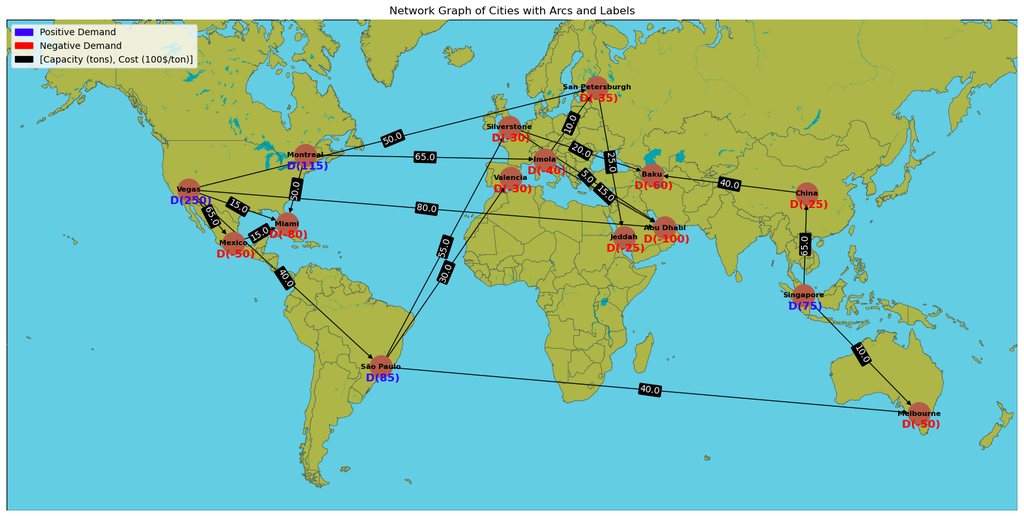

```python
# Extract the optimized values
flows = [value(model.x[j]) for j in model.Arcs]

# Create a graph for the optimized flows
G_optimized = nx.DiGraph()

# Add nodes with coordinates
for node, coord in coordinates.items():
    G_optimized.add_node(node, pos=coord)

# Add edges with non-zero optimized flows
for j, arc in enumerate(arcs):
    initial_node, final_node = arc
    flow = flows[j]
    if flow != 0:  # Only add edges with non-zero flows
        G_optimized.add_edge(initial_node, final_node, flow=flow)

# Draw the graph on a map
fig, ax = plt.subplots(figsize=(20, 16))
m = Basemap(projection='merc', llcrnrlat=-60, urcrnrlat=70, llcrnrlon=-180, urcrnrlon=180, resolution='l')
m.drawcoastlines(color='#3d5758', linewidth=1, zorder= 1)
m.drawmapboundary(fill_color='#63cde3')  # Set the background to blue
m.fillcontinents(color='#adb647', lake_color='#05a3ad')

pos = {node: m(coord[1], coord[0]) for node, coord in coordinates.items()}
nx.draw(G_optimized, pos, with_labels=True, font_size=8, font_color='black', node_size=600, node_color='#b65d48', font_weight='bold', ax=ax)  # Bring nodes and labels to the front

# Add edge labels with capacity and time cost on top of the line
edge_labels = {(arc[0], arc[1]): f"{flow}" for arc, flow in zip(arcs, flows) if flow != 0}
m.drawcountries(color='#3d5758', linewidth=0.5,  zorder= 1 )  # Set the border color to white
nx.draw_networkx_edge_labels(G_optimized, pos, edge_labels=edge_labels, font_color='white', ax=ax, label_pos=0.5, font_size=10, bbox=dict(facecolor='black', edgecolor='black', boxstyle='round,pad=0.1'))

# ADDING demand to the nodes
node_demand = dict(zip(nodes, demand))
node_labels = {node: f"\n\n D({node_demand[node]})" if node_demand[node] != 0 else f'' for node in nodes}

# Draw labels with color-coding
for node, label in node_labels.items():
    color = '#3b00fd' if node_demand[node] > 0 else '#FF0000'
    nx.draw_networkx_labels(G, pos, labels={node: label}, font_color=color, ax=ax, font_size=12, font_weight='bold')

# Create custom legend
legend_labels = [
    mpatches.Patch(color='#3b00fd', label='Positive Demand'),
    mpatches.Patch(color='#FF0000', label='Negative Demand'),
    mpatches.Patch(color='black', label='[Capacity (tons), Cost (100$/ton)]'),
]

plt.legend(handles=legend_labels, loc='upper left')
plt.title('Network Graph of Cities with Arcs and Labels')
plt.show()
```

Now we are seeing the amount of money spent on the links.

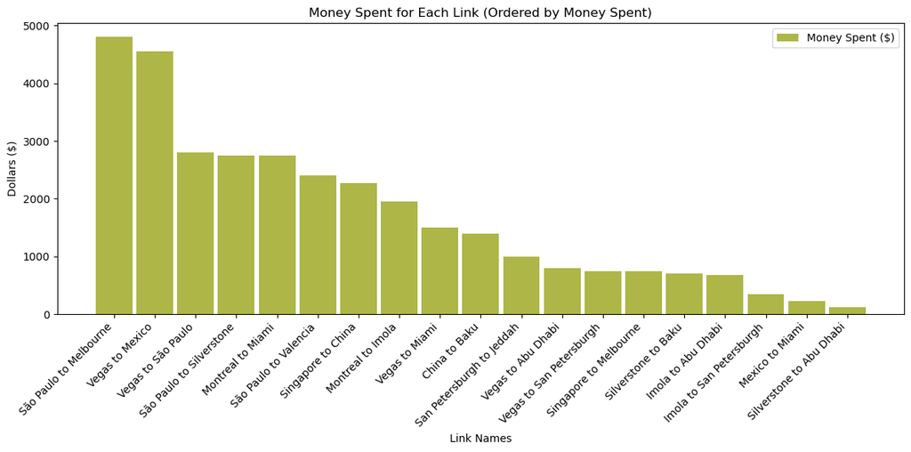

```python
# Extract the solution values
money_spent = [model.Cost[j] * model.x[j]() for j in model.Arcs]
link_names = [f"{arc[0]} to {arc[1]}" for arc in arcs]  # Construct link names using the arcs

# Remove links with zero money spent
non_zero_indices = [i for i, value in enumerate(money_spent) if value != 0]
link_names = [link_names[i] for i in non_zero_indices]
money_spent = [money_spent[i] for i in non_zero_indices]

# Sort data by money spent
sorted_indices = sorted(range(len(money_spent)), key=lambda k: money_spent[k], reverse=True)
link_names = [link_names[i] for i in sorted_indices]
money_spent = [money_spent[i] for i in sorted_indices]

# Create a bar plot
fig, ax = plt.subplots(figsize=(12, 6))
bar_width = 0.9
index = range(len(link_names))

# Bar for money spent
bars3 = ax.bar(index, money_spent, bar_width, label='Money Spent ($)', color='#adb647')  # Adjusted x-coordinates

# Add labels, title, and legend
ax.set_xlabel('Link Names')
ax.set_ylabel('Dollars ($)')
ax.set_title('Money Spent for Each Link (Ordered by Money Spent)')
ax.set_xticks(index)
ax.set_xticklabels(link_names, rotation=45, ha="right")  # Rotate labels by 45 degrees
ax.legend()

# Show the plot
plt.tight_layout()
plt.show()
```

```python
print("The amount of money invested this F1 season in moving", 525, "tons of cargo is", 100*model.objective(), "$") # we multiply by 100 as the units are 100$/ton
```

```
The amount of money invested this F1 season in moving 525 tons of cargo is 3255000.0 $
```

So, to conclude for this part of the project, we have computed the optimal paths to select so that the demand on the F1 calendar is fitted and the cost is minimized as maximum as possible. We can see that we have spent around 3.25 million $, to move 525 tons of technical equipment for the races that has been developed in 4 cities (Montreal, São Paulo, Singapore and Vegas).

# Project 2, Part2, Formula 1 Aerodynamics Optimization

In Formula 1, optimizing aerodynamics is crucial for achieving high performance. Let's consider a 3D objective function aimed at minimizing the aerodynamic drag force on a Formula 1 car. The objective function takes into account the car's speed, the angle of attack, and the air density.

The aerodynamic drag force is given by the equation:

\begin{align*} F_{\text{drag}} = \frac{1}{2} \rho v^2 C_d A \end{align*}

Where: \begin{align*} \rho & : \text{Air density (kg/m}^3\text{)} \\ v & : \text{flow velocity (km/h)} \\ C_d & : \text{Drag coefficient (nonlinear, dependent on \(\alpha\))} \\ A & : \text{Frontal area of the car (m}^2\text{)} \end{align*}

The drag coefficient is assumed to be nonlinear and dependent on the angle of attack, alpha:

\begin{align*} C_d = 0.1 + 0.01 \alpha^2 \end{align*}

The angle of attack (alpha) for an Formula 1 car can vary depending on the design, aerodynamic philosophy, and specific conditions. However:

Negative Values (Downforce): Formula 1 cars are designed to generate downforce to improve grip on the track. Negative alpha (where the front wing is angled downward and the rear wing is angled upward) helps generate downforce. Typical values for negative alpha range from -5 degrees to -2 degrees.

Positive Values (Top Speed): In some situations, teams might adjust the alpha to reduce drag and maximize top speed. Positive alpha (front wing angled slightly upward, rear wing angled downward) can help decrease downforce and aerodynamic drag on straight portions of the track. Positive values may range from 1 to 3 degrees.

It's important to note that these values can vary significantly between teams and even between different tracks. Teams optimize the aerodynamics based on the characteristics of each circuit, considering the balance between downforce and drag for optimal performance.

During this practice, we are going to try to optimize the drag force for the most extreme case, where we want to have the minimum possible drag.

Defining the variables thresholds:

```python
min_speed = 280
max_speed = 325

min_alpha = -5
max_alpha = 3

min_rho = 1.2
max_rho = 1.65

min_area = 1.7
max_area = 2.5
```

Defining the functions we are going to use:

```python
# Fix values for rho and area at their average minimum values
avg_min_rho = (min_rho + max_rho) / 2 ; print("Average rho:",avg_min_rho)
avg_min_area = (min_area + max_area) / 2  ; print("Average area:",avg_min_area)

def drag_coeff(alpha):
    Cd = 0.1 + 0.01 * alpha**2
    return Cd

# Function to calculate the objective value (aerodynamic drag force)
def aerodynamic_drag(v, alpha, rho, A):
    Cd = drag_coeff(alpha)
    # Aerodynamic drag force formula
    F_drag = 0.5 * rho * v**2 * Cd * A
    return F_drag
```

```
Average rho: 1.4249999999999998
Average area: 2.1
```

We are going to show an example of how this drag force depends on the variables:

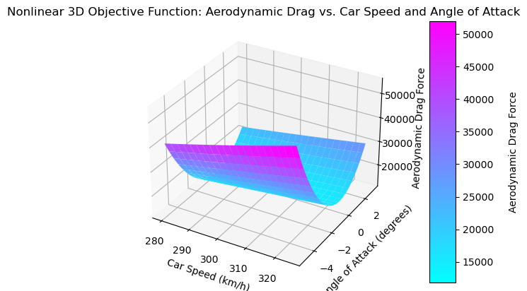

```python
# Generate data for plotting
speed_values = np.linspace(min_speed, max_speed, 100)
alpha_values = np.linspace(min_alpha, max_alpha, 100)

# Create 2D meshgrid
speed_mesh, alpha_mesh = np.meshgrid(speed_values, alpha_values, indexing='ij')

# Calculate aerodynamic drag force for each data point
drag_force_values = aerodynamic_drag(speed_mesh, alpha_mesh, avg_min_rho, avg_min_area)

# Plotting with legend
fig = plt.figure()
ax = fig.add_subplot(111, projection='3d')
surface = ax.plot_surface(speed_mesh, alpha_mesh, drag_force_values, cmap='cool', rstride=5, cstride=5)
ax.set_xlabel('Car Speed (km/h)')
ax.set_ylabel('Angle of Attack (degrees)')
ax.set_zlabel('Aerodynamic Drag Force')
ax.set_title('Nonlinear 3D Objective Function: Aerodynamic Drag vs. Car Speed and Angle of Attack')

# Add colorbar
cbar = fig.colorbar(surface, ax=ax, pad=0.1, aspect=10)
cbar.set_label('Aerodynamic Drag Force')
cbar.ax.get_yaxis().labelpad = 15  # Adjust padding for the colorbar label

plt.show()
```

# Model Definition

\begin{align} \text{Minimize:} & \quad F_{\text{drag}} = \frac{1}{2} \rho v^2 C_d A \\ \end{align}

\begin{align*} \text{Where:} & \\ \rho & : \text{Air density (kg/m}^3\text{)} \\ v & : \text{flow velocity (km/h)} \\ C_d & : \text{Drag coefficient (nonlinear, dependent on \(\alpha\))} \\ A & : \text{Frontal area of the car (m}^2\text{)} \end{align*}

\begin{align*} \text{Subject to:} & \\ & \quad \text{Air-Area Flow Constraint:} \quad car speed \leq \text{100 * (rho * area)}\\ & \quad \text{Car Speed Constraint:} \quad \text{Air Flow Velocity} \geq 280, \quad \text{Air Flow Velocity} \leq 325 \\ & \quad \text{Angle of Attack Constraint:} \quad -5 \leq \text{alpha} \leq 3\\ & \quad \text{Air Density Constraint:} \quad 1.2 \leq \text{rho} \leq 1.65\\ & \quad \text{Front Area Constraint:} \quad 1.7 \leq \text{area} \leq 2.5\\ \end{align*}

- Air-Area relation must be seriously taken into account. If this value exceeds is just 1% the speed of the car, we enter into the danger zone where turbulent air could be produced and the pilot could lose control.
- Speed of the car must be bounded to the circuit capabilities. As we are focusing on the straights, speed will be on the range 280 to 325 kilometers per hour.
- Angle of attack is the inclination of the car as we explained above.
- Air density will depend on the part of the circuit in which we are.
- The front area is a parameter that can be adjusted by replacing the front wing to another one. That is why we have different possible areas.

```python
# Create a Pyomo concrete model
model2 = ConcreteModel("Drag Force Optimization")

# Variables
model2.car_speed = Var(within=NonNegativeReals, doc = "air flow due to car speed (km/h)")
model2.alpha = Var(within=Reals, doc = "angle of attack (degrees)")
model2.rho = Var(within=NonNegativeReals, doc = "Air density (kg/m^3)")
model2.area = Var(within=NonNegativeReals, doc = "Frontal area of the car (m^2)")

# Objective function with multiple components
model2.obj = Objective(expr=aerodynamic_drag(model2.car_speed, model2.alpha, model2.rho, model2.area),
                       doc = "Minimize the Aerodynamic Drag", sense=minimize)

# Constraints:

# Air-Flow security limitation (turbulent air)
def area_air_flow_constraint(car_speed, rho, area):
    return (car_speed) <= 100 * (rho * area)
model2.area_air_flow = Constraint(expr=area_air_flow_constraint(model2.car_speed, model2.rho, model2.area), doc="Maximum Speed Air Flow")

# Angle of attack bounds
model2.alpha_lower_bound = Constraint(expr=model2.alpha >= min_alpha, doc = "Minimum Allowed Angle Of Attack")
model2.alpha_upper_bound = Constraint(expr=model2.alpha <= max_alpha, doc = "Maximum Allowed Angle Of Attack")

# Bounds for the Rho, the air density.
model2.rho_lower_bound = Constraint(expr=model2.rho >= min_rho, doc = "Minimum Allowed Air density")
model2.rho_upper_bound = Constraint(expr=model2.rho <= max_rho, doc = "Maximum Allowed Air density")

# Speed bounds
model2.speed_lower_bound = Constraint(expr=model2.car_speed >= min_speed, doc = "Minimum Allowed Speed")
model2.speed_upper_bound = Constraint(expr=model2.car_speed <= max_speed, doc = "Maximum Allowed Speed")

# Bounds for the area of the front of the car
model2.area_lower_bound = Constraint(expr=model2.area >= min_area, doc = "Minimum Allowed Area")
model2.area_upper_bound = Constraint(expr=model2.area <= max_area, doc = "Maximum Allowed Area")
```

We should notice that for this equation, the velocity is quadratic and so is the angle of attack. As we are going to multiply 2 quadratic terms, our function is going to be in 4 dimensions. This means that we cannot apply conventional solvers, we can use one of the best ones for non linear cases that is ipopt.

```python
solver = SolverFactory('ipopt')
result = solver.solve(model2)
print("Solution Status:",  result)
```

```
Solution Status:
Problem:
- Lower bound: -inf
  Upper bound: inf
  Number of objectives: 1
  Number of constraints: 9
  Number of variables: 4
  Sense: unknown
Solver:
- Status: ok
  Message: Ipopt 3.14.6\x3a Optimal Solution Found
  Termination condition: optimal
  Id: 0
  Error rc: 0
  Time: 0.02102065086364746
Solution:
- number of solutions: 0
  number of solutions displayed: 0
```

```python
model2.display()
```

```
Model Drag Force Optimization

  Variables:
    car_speed : air flow due to car speed (km/h)
        Size=1, Index=None
        Key  : Lower : Value             : Upper : Fixed : Stale : Domain
        None :     0 : 279.9999972000213 :  None : False : False : NonNegativeReals
    alpha : angle of attack (degrees)
        Size=1, Index=None
        Key  : Lower : Value                   : Upper : Fixed : Stale : Domain
        None :  None : -1.5220945411553526e-13 :  None : False : False :  Reals
    rho : Air density (kg/m^3)
        Size=1, Index=None
        Key  : Lower : Value              : Upper : Fixed : Stale : Domain
        None :     0 : 1.3870478395624428 :  None : False : False : NonNegativeReals
    area : Frontal area of the car (m^2)
        Size=1, Index=None
        Key  : Lower : Value              : Upper : Fixed : Stale : Domain
        None :     0 : 2.0186758466702486 :  None : False : False : NonNegativeReals

  Objectives:
    obj : Size=1, Index=None, Active=True
        Key  : Active : Value
        None :   True : 10975.999670333018

  Constraints:
    area_air_flow : Size=1
        Key  : Lower : Body                  : Upper
        None :  None : 9.936002243193798e-09 :   0.0
    alpha_lower_bound : Size=1
        Key  : Lower : Body                    : Upper
        None :  -5.0 : -1.5220945411553526e-13 :  None
    alpha_upper_bound : Size=1
        Key  : Lower : Body                    : Upper
        None :  None : -1.5220945411553526e-13 :   3.0
    rho_lower_bound : Size=1
        Key  : Lower : Body               : Upper
        None :   1.2 : 1.3870478395624428 :  None
    rho_upper_bound : Size=1
        Key  : Lower : Body               : Upper
        None :  None : 1.3870478395624428 :  1.65
    speed_lower_bound : Size=1
        Key  : Lower : Body              : Upper
        None : 280.0 : 279.9999972000213 :  None
    speed_upper_bound : Size=1
        Key  : Lower : Body              : Upper
        None :  None : 279.9999972000213 : 325.0
    area_lower_bound : Size=1
        Key  : Lower : Body               : Upper
        None :   1.7 : 2.0186758466702486 :  None
    area_upper_bound : Size=1
        Key  : Lower : Body               : Upper
        None :  None : 2.0186758466702486 :   2.5
```

```python
optimal_speed = model2.car_speed()
optimal_alpha = model2.alpha()
optimal_rho = model2.rho()
optimal_area = model2.area()

# Display the results
print(f"Optimal Car Speed: {optimal_speed} km/h")
print(f"Optimal Angle of Attack: {optimal_alpha} degrees")
print(f"Optimal Air Density: {optimal_rho} kg/m^3")
print(f"Optimal Frontal Area: {optimal_area} m^2")
print(f"Minimum Aerodynamic Drag Force: {model2.obj()} N")
```

```
Optimal Car Speed: 279.9999972000213 km/h
Optimal Angle of Attack: -1.5220945411553526e-13 degrees
Optimal Air Density: 1.3870478395624428 kg/m^3
Optimal Frontal Area: 2.0186758466702486 m^2
Minimum Aerodynamic Drag Force: 10975.999670333018 N
```

We are going to show the 3D plot of this optimal point:

```python
#  First define the grid of points
speed_values = np.linspace(min_speed, max_speed, 100)
alpha_values = np.linspace(min_alpha, max_alpha, 100)
speed_mesh, alpha_mesh = np.meshgrid(speed_values, alpha_values)
drag_values = np.zeros_like(speed_mesh)

for i in range(len(speed_values)):
    for j in range(len(alpha_values)):
        speed_val = speed_values[i]
        alpha_val = alpha_values[j]
        drag_values[j, i] = aerodynamic_drag(speed_val, alpha_val,optimal_rho, optimal_area)  # optimal 'rho' and 'A'
```

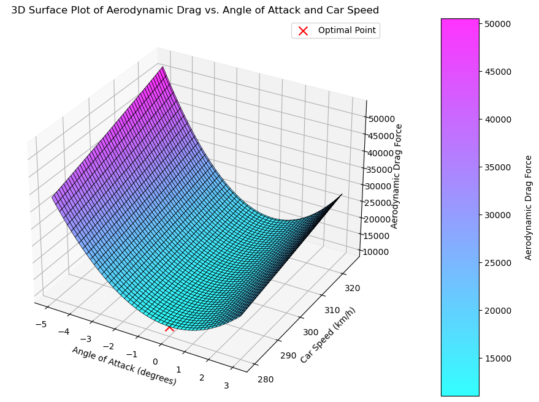

```python
# 3D surface plot
fig = plt.figure(figsize=(12, 8))
ax = fig.add_subplot(111, projection='3d')
surf = ax.plot_surface(alpha_mesh, speed_mesh, drag_values, cmap='cool', edgecolors='k', linewidth=0.5, alpha=0.8)

# Optimal point scatter plot
ax.scatter(optimal_alpha, optimal_speed, aerodynamic_drag(optimal_speed, optimal_alpha, optimal_rho, optimal_area),
           color='red', marker='x', s=100, label='Optimal Point')

# Add colorbar
cbar = fig.colorbar(surf, pad=0.1, aspect=10)
cbar.set_label('Aerodynamic Drag Force')
cbar.ax.get_yaxis().labelpad = 15  # Adjust padding for the colorbar label

# Set labels and title
ax.set_xlabel('Angle of Attack (degrees)')
ax.set_ylabel('Car Speed (km/h)')
ax.set_zlabel('Aerodynamic Drag Force')
ax.set_title('3D Surface Plot of Aerodynamic Drag vs. Angle of Attack and Car Speed')

# Show legend
ax.legend()

plt.show()
```

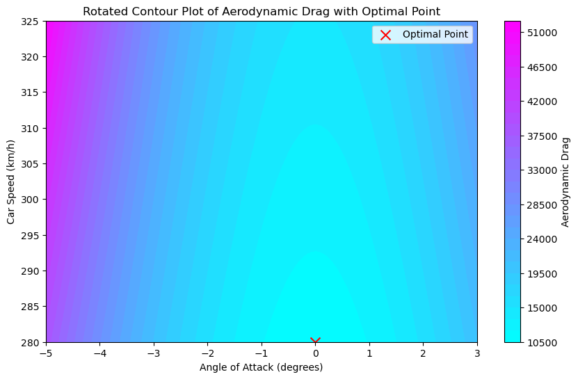

```python
# Plot the rotated contour plot
plt.figure(figsize=(10, 6))
contour = plt.contourf(alpha_mesh, speed_mesh, drag_values, levels=30, cmap='cool')  # Swap x-axis and y-axis
plt.colorbar(contour, label='Aerodynamic Drag')

# Scatter plot for the optimal point
plt.scatter(optimal_alpha, optimal_speed, color='red', marker='x', label='Optimal Point', s=100)

plt.xlabel('Angle of Attack (degrees)')
plt.ylabel('Car Speed (km/h)')  # Swap x-axis and y-axis
plt.title('Rotated Contour Plot of Aerodynamic Drag with Optimal Point')
plt.legend()
plt.show()
```

As in the previous plot, this is just a 2D visualization that corroborates the previous data, the lowest point is selected.

Now we are going to check for the values between the Area of the front of the car and the Air density:

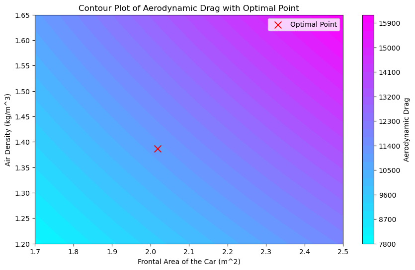

```python
import matplotlib.pyplot as plt
import numpy as np

# Define the range of air density and area values
rho_values = np.linspace(min_rho, max_rho, 100)
area_values = np.linspace(min_area, max_area, 100)

# Create 2D meshgrid
Rho, Area = np.meshgrid(rho_values, area_values, indexing='ij')

# Calculate aerodynamic drag force for each data point
drag_values = aerodynamic_drag(optimal_speed, optimal_alpha, Rho, Area)

# Plotting with legend
fig = plt.figure(figsize=(10, 6))
contour = plt.contourf(Area, Rho, drag_values, levels=30, cmap='cool')
plt.colorbar(contour, label='Aerodynamic Drag')

# Scatter plot for the optimal point
plt.scatter(optimal_area, optimal_rho, color='red', marker='x', label='Optimal Point', s=100)

plt.xlabel('Frontal Area of the Car (m^2)')
plt.ylabel('Air Density (kg/m^3)')
plt.title('Contour Plot of Aerodynamic Drag with Optimal Point')
plt.legend()
plt.show()
```

We can see that due to our Air-Area flow constraint, an optimal solution is chosen that is not that obvious. This is due to the fact that the speed of the car should not be larger than the product of the air flow and the area, due to the fact that we could have turbulent air. A medium sized wing should be selected for the car together with a middle height circuit where the air density is medium (1.38 kg/m^3).

We can also compare the air density with the car speed in a 2D plot, but the answer is obvious:

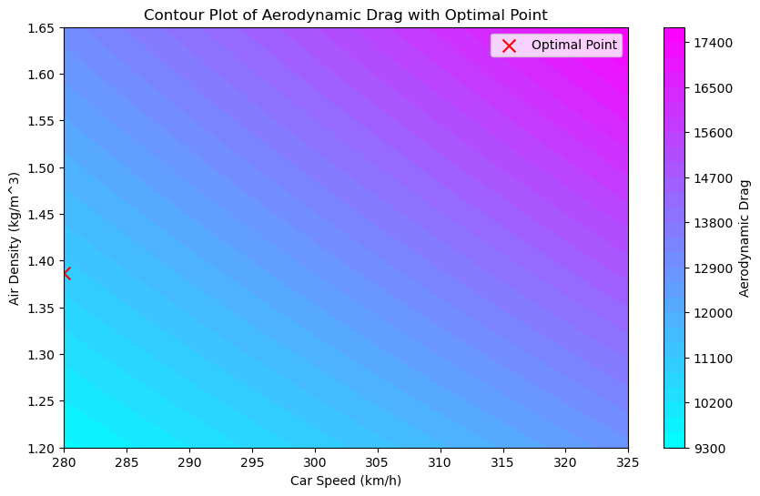

```python
import matplotlib.pyplot as plt
import numpy as np

# Define the range of air density and speed values
rho_values = np.linspace(min_rho, max_rho, 100)
speed_values = np.linspace(min_speed, max_speed, 100)

# Create 2D meshgrid
Rho, Speed = np.meshgrid(rho_values, speed_values, indexing='ij')

# Calculate aerodynamic drag force for each data point
drag_values = aerodynamic_drag(Speed, optimal_alpha, Rho, optimal_area)

# Plotting with legend
fig = plt.figure(figsize=(10, 6))
contour = plt.contourf(Speed, Rho, drag_values, levels=30, cmap='cool')
plt.colorbar(contour, label='Aerodynamic Drag')

# Scatter plot for the optimal point
plt.scatter(optimal_speed, optimal_rho, color='red', marker='x', label='Optimal Point', s=100)

plt.xlabel('Car Speed (km/h)')
plt.ylabel('Air Density (kg/m^3)')
plt.title('Contour Plot of Aerodynamic Drag with Optimal Point')
plt.legend()
plt.show()
```

Here we can see that the minimum speed is selected in order to minimize the drag, while the air density is not. This is due to the Air-Area constraint that we have.

Finally, let´s plot a 3D version of our problem, but now focusing on the air and area together with the speed:

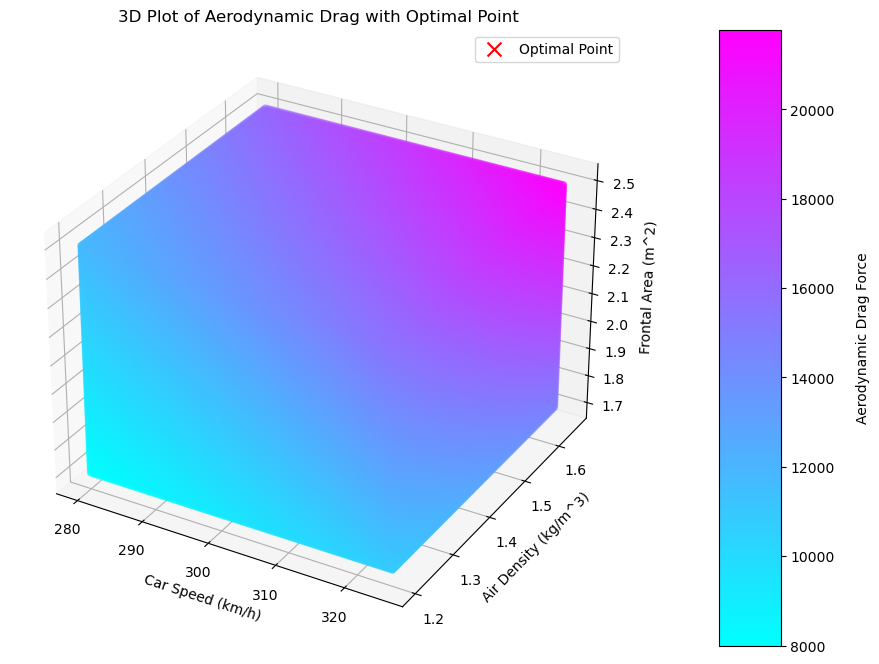

```python
import matplotlib.pyplot as plt
import numpy as np
from mpl_toolkits.mplot3d import Axes3D

# Define the range of air density, car speed, and frontal area values
rho_values = np.linspace(min_rho, max_rho, 100)
speed_values = np.linspace(min_speed, max_speed, 100)
area_values = np.linspace(min_area, max_area, 100)

# Create 3D meshgrid
Rho, Speed, Area = np.meshgrid(rho_values, speed_values, area_values, indexing='ij')

# Calculate aerodynamic drag force for each data point
drag_values = aerodynamic_drag(Speed, optimal_alpha, Rho, Area)

# Plotting with legend
fig = plt.figure(figsize=(12, 8))
ax = fig.add_subplot(111, projection='3d')
surface = ax.scatter3D(Speed.flatten(), Rho.flatten(), Area.flatten(), c=drag_values.flatten(), cmap='cool', marker='o')

# Scatter plot for the optimal point
ax.scatter(optimal_speed, optimal_rho, optimal_area, color='red', marker='x', s=100, label='Optimal Point')

ax.set_xlabel('Car Speed (km/h)')
ax.set_ylabel('Air Density (kg/m^3)')
ax.set_zlabel('Frontal Area (m^2)')
ax.set_title('3D Plot of Aerodynamic Drag with Optimal Point')

# Add colorbar and legend
cbar = fig.colorbar(surface, ax=ax, pad=0.1, aspect=10)
cbar.set_label('Aerodynamic Drag Force')
cbar.ax.get_yaxis().labelpad = 15  # Adjust padding for the colorbar label

plt.legend()
plt.show()
```

So finally, we can see that the obtained values in order to minimize the drag force are to reduce all the parameters. There is an exception related to the Air-Area maximum flow, that as we explained does not allow the cars to increase this treshold for security reasons as turbulent air could be produced.